# Homework 2: Differential Gene Expression Analysis

Almog Angel

12/12/2024

- **Objective:** Perform a differential gene expression (DGE) analysis using RNA-Seq data.

## Step 1: Load Required Packages and Set Working Directory

```r
library(DESeq2)
library(ashr)
library(EnhancedVolcano)
library(factoextra)
library(clusterProfiler)
library(msigdbr)
library(tidyverse)
library(GEOquery)
```

```r
library(dplyr)
library(ggplot2)
#setwd("path/to/your/working/directory")
```

## Step 2: Research Context

- Read the abstract of the study “Temporal changes in postprandial blood transcriptomes reveal subject-specific patterns of expression of innate immunity genes after a high-fat meal” (PDF file attached - “Lemay_2019”).
- Answer the following questions using in your own words (not ChatGPT’s):
  1. Explain the term “whole blood transcriptome” (up to 100 words).
  2. Summarize the objective and design of the study (up to 250 words). ```{} Write your answers here:
1. whole blood transcriptome is a record of the genes who were expressed into protein in the blood cells (white blood cells) using RNA sequencing.
2. The researchers wanted to determine the effect of DHA and blueberries after a high fat meal. they measured the RNA expressed during digesting each compound in regards to the time of day and fasting hours.

````
## Step 3: Retrieve Data from GEO

- Locate the Gene Expression Omnibus (GEO) accession number in the manuscript.
- Write it below:
```{}
GEO accession number:GSE127530
````

- Download the counts data (the second one: “fixed”) and Series Matrix File(s) from the GEO website.
- Load the count matrix and metadata into the corresponding variables below

```r
counts <- read.table("GSE127530_fixed_combinedCounts.txt.gz",
                     stringsAsFactors = FALSE, sep = '\t',
                     header = TRUE, check.names = FALSE)
metadata <- getGEO(filename = "GSE127530_series_matrix.txt")
metadata_pdata <- pData(metadata)
```

## Step 4: Prepare Data

- Convert `metadata` to a tibble.
- Select and rename the following columns:
  - `Sample` = `description`
  - `Subject` = `study subject id #:ch1`
  - `Day` = `test day:ch1`
  - `Time` = `time of blood draw:ch1`
- Ensure the `Time` column is a factor.

```r
# Implement your code here:
metadata <- as_tibble(metadata_pdata) %>%
  dplyr::select(
    Sample = `description`,
    Subject = `study subject id #:ch1`,
    Day = `test day:ch1`,
    Time = `time of blood draw:ch1`
  ) %>%
  mutate(Time = as.factor(Time))
```

In R, factors are used to represent categorical variables, and these factors have levels that dictate their ordering. When performing statistical analysis, the first level of a factor is treated as the reference level. Other levels are compared against this reference

- Make “fasting” the reference level for `Time`.

```r
metadata$Time <- relevel(metadata$Time, ref="fasting")
```

- Remove genes with zero total counts.

```r
# Implement your code here:
counts <- counts[rowSums(counts[,-1]) > 0, ]
```

## Step 5: Run DESeq2

- Make a DESeq2 object called `dds` and use the `Time` column for the design

```r
# Implement your code here:
dds <- DESeqDataSetFromMatrix(
  countData = counts,            # The raw count matrix
  colData = metadata,                 # Metadata data frame
  design = ~ Time                     # Experimental design using the "Time" column
)
```

```
##   Note: levels of factors in the design contain characters other than
##   letters, numbers, '_' and '.'. It is recommended (but not required) to use
##   only letters, numbers, and delimiters '_' or '.', as these are safe characters
##   for column names in R. [This is a message, not a warning or an error]
```

```r
rownames(dds) <- counts[, 1]          # Assign rownames from gene column
```

- Perform the differential expression analysis with DESeq2.

```r
# Implement your code here:
dds <- DESeq(dds)
```

```
##   Note: levels of factors in the design contain characters other than
##   letters, numbers, '_' and '.'. It is recommended (but not required) to use
##   only letters, numbers, and delimiters '_' or '.', as these are safe characters
##   for column names in R. [This is a message, not a warning or an error]
```

[output not shown]

[output not shown]

```
## -- replacing outliers and refitting for 12 genes
## -- DESeq argument 'minReplicatesForReplace' = 7
## -- original counts are preserved in counts(dds)
```

[output not shown]

- We are now comparing the groups of fasting and time = 3 hours
- Use the function lfcShrink() to adjust the LFC values with the following arguments:
  1. coef=“Time_3.hr.postprandial_vs_fasting” for the name of the coefficient to shrink
  2. type=“apeglm”
- Store the results back into `res`

```r
# Implement your code here:
res <- lfcShrink(dds, coef = "Time_3.hr.postprandial_vs_fasting", type = "apeglm")
```

```
## using 'apeglm' for LFC shrinkage. If used in published research, please cite:
##     Zhu, A., Ibrahim, J.G., Love, M.I. (2018) Heavy-tailed prior distributions for
##     sequence count data: removing the noise and preserving large differences.
##     Bioinformatics. https://doi.org/10.1093/bioinformatics/bty895
```

[output not shown]

[output not shown]

- Sort `res` by the adjusted p-values from lowest to highest and store in `resOrdered`

```r
# Implement your code here:
resOrdered <- res[order(res$padj),]
significant_genes <- resOrdered[which(resOrdered$padj < 0.05), ]
num_significant_genes <- nrow(significant_genes)
num_significant_genes
```

```
## [1] 3
```

- Write the number of significant genes (padj < 0.05):

```
Number of significant genes: 3
```

## Step 6: Perform PCA

- Use the function `vst()` to extract the normalized counts from `dds` into `counts.vst`

```r
# Implement your code here:
counts.vst <- assay(vst(dds, blind = FALSE))
```

- Use the function `plotPCA()` to generate a ggplot2 object for the PCA visualization and store it into `pcaData`:
  1. Use the top 1000 variable genes
  2. Use `intgroup=c("Subject", "Day")` for grouping
  3. Use `returnData = TRUE`

```r
# Implement your code here:
pcaData <- plotPCA(vst(dds,blind=FALSE), ntop=1000, intgroup=c("Subject", "Day"), returnData = TRUE)
```

```
## using ntop=1000 top features by variance
```

- Use ggplot to plot the object you made above:
- Plot the percent of variance explained in PC1 and PC2 labels

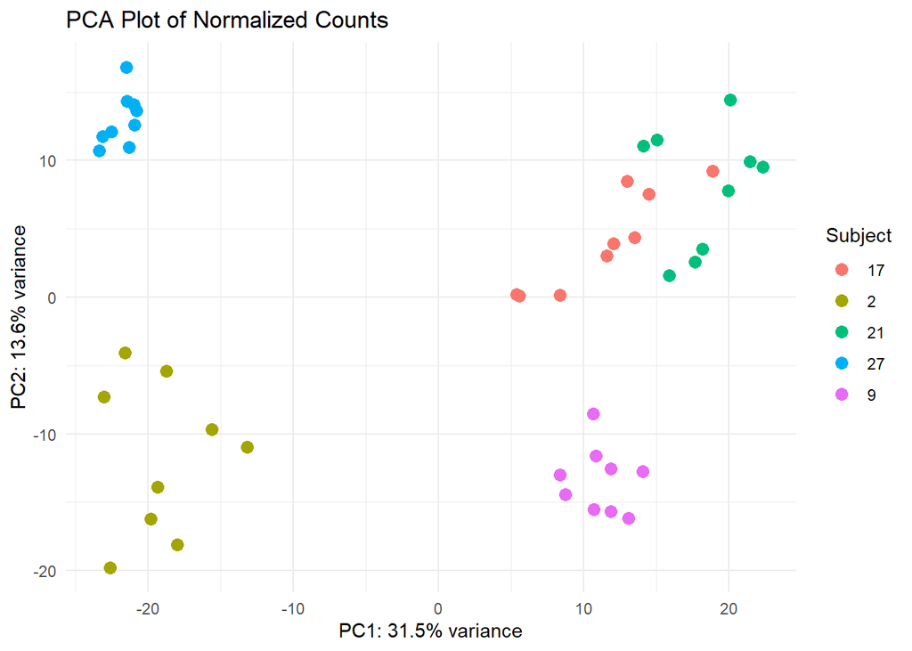

```r
# Implement your code here:
# Perform PCA on the VST-normalized counts
pca_data <- prcomp(t(counts.vst))

# Get variance explained for PC1 and PC2
percentVar <- (pca_data$sdev^2) / sum(pca_data$sdev^2) * 100
percentVar <- round(percentVar, 1)

# Create a data frame for plotting
pca_df <- data.frame(PC1 = pca_data$x[, 1],
                     PC2 = pca_data$x[, 2],
                     Subject = colData(dds)$Subject) # Add metadata for grouping

# Generate PCA plot using ggplot2
pca_plot <- ggplot(pca_df, aes(x = PC1, y = PC2, color = Subject)) +
  geom_point(size = 3) +
  labs(
    title = "PCA Plot of Normalized Counts",
    x = paste0("PC1: ", percentVar[1], "% variance"),
    y = paste0("PC2: ", percentVar[2], "% variance")
  ) +
  theme_minimal()

pca_plot
```

- Answer the following questions using in your own words (not ChatGPT’s):
  1. What is the purpose of Principal Component Analysis (PCA) in data analysis? (up to 150 words)
  2. What do the axes labeled “PC1” and “PC2” mean? (up to 100 words) ```{} Write your answer here:
1. PCA reduce the number of dimentions by projecting the data on less dimentions (2). this way we can categories the data into clusters and see it visualy easier. (2)PC1 and PC2 are component axis with the highest variance, which the algorithm fitted as the best clusters(PC1>PC2).The more variability captured by PC1, the more information is retained from the original dataset. PC2 must be uncorrelated with PC1, meaning it is orthogonal (perpendicular) to PC1. This orthogonality ensures that the correlation between PC1 and PC2 is zero.

[output not shown]

[figure not shown]

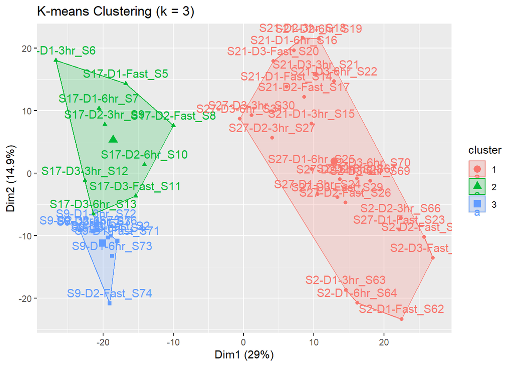

```r
# Run K-means clustering with k = 3
kmeans_out <- kmeans(normcounts.top1Kvar, centers = 3, nstart = 25)

# Visualize clusters
fviz_cluster(kmeans_out, data = normcounts.top1Kvar) +
  ggtitle("K-means Clustering (k = 3)")
```

- Based on the PCA and the clustering you made above:
  1. Is your clustering result consistent with the PCA plot? describe. yes/no
  2. What is the main source of variation among samples in this study? explain what led you to this conclusion? (up to 150 words)
  3. Do you think this source of variation is essential for our analysis? why? (up to 150 words)
  4. Suggest another source of variation and explain what led you to this conclusion? (up to 150 words)
- Support your answers using the PCA/clustering plots and adjust the code as needed to justify your conclusions.

[output not shown]

- Hint: Look at Figure 1A in the manuscript.

## Step 8: Update DESeq2 Design

- Make a second DESeq2 object called `dds2`.
- This time make use of the insights you gained above into the `design` formula.

```r
# Implement your code here:
# Define design formula with two factors (additive model)
dds2 <- DESeqDataSetFromMatrix(countData = counts, colData = metadata, design = ~ Subject + Time)
```

```
##   Note: levels of factors in the design contain characters other than
##   letters, numbers, '_' and '.'. It is recommended (but not required) to use
##   only letters, numbers, and delimiters '_' or '.', as these are safe characters
##   for column names in R. [This is a message, not a warning or an error]
```

- How does the new object differ from the original one? Explain why these changes are expected to improve the results. (up to 150 words)

```
Write your answer here:
We chose to do the new design with adding "Time" to the "Subject" element, as it is the most contributing to the variance and we can't nullify each subject gene expression.
```

- Run DESeq() and lfcShrink() again, save the results into `res2` and sort by adjusted p-value in `resOrdered2`

```r
# Implement your code here:
dds2 <- DESeq(dds2)
```

```
##   Note: levels of factors in the design contain characters other than
##   letters, numbers, '_' and '.'. It is recommended (but not required) to use
##   only letters, numbers, and delimiters '_' or '.', as these are safe characters
##   for column names in R. [This is a message, not a warning or an error]
```

```
##   Note: levels of factors in the design contain characters other than
##   letters, numbers, '_' and '.'. It is recommended (but not required) to use
##   only letters, numbers, and delimiters '_' or '.', as these are safe characters
##   for column names in R. [This is a message, not a warning or an error]
```

```r
res2 <- lfcShrink(dds2, coef = "Time_3.hr.postprandial_vs_fasting", type = "apeglm")
```

```
## using 'apeglm' for LFC shrinkage. If used in published research, please cite:
##     Zhu, A., Ibrahim, J.G., Love, M.I. (2018) Heavy-tailed prior distributions for
##     sequence count data: removing the noise and preserving large differences.
##     Bioinformatics. https://doi.org/10.1093/bioinformatics/bty895
```

```r
resOrdered2 <- res2[order(res2$pvalue),]
significant_genes2 <- res2[which(res2$padj < 0.05), ]
num_significant_genes2 <- nrow(significant_genes2)
num_significant_genes2
```

```
## [1] 63
```

- How many significant genes (adjusted p-value < 0.05) did you get this time?

```
Write your answer here:
63
```

- Explain in short the meaning of each column in `resOrdered2`

```
Write your answer here:
baseMean - The average normalized expression level of a gene across all samples.
log2FoldChange  - The log2 ratio of expression levels between the comparison groups. Positive values indicate upregulation, and negative values indicate downregulation for the comparison.
lfcSE  - (Log Fold Change Standard Error) The standard error of the log2 fold change estimate. Reflects the uncertainty in the estimated fold change.
pvalue - The raw p-value from the statistical test, representing the probability of observing the data if the null hypothesis is true.
padj - he adjusted p-value using the Benjamini-Hochberg procedure to control the false discovery rate (FDR). Genes with padj < 0.05 are considered significantly differentially expressed.
```

- Select 3-5 genes of interest from the most differentially expressed genes (DEGs).
- Search for their names online to identify if they share any common characteristics.
- In your response, list the genes you chose and describe what you discovered about them.

```
Write your answer here:
MARC1- Involved in cellular detoxification of nitrogen compound, Chromosome 1, Biased expression in fat and thyroid.
ACSL4 - The protein encoded by this gene is an isozyme of the long-chain fatty-acid-coenzyme A ligase family
ZBTB7B - This gene encodes a zinc finger-containing transcription factor that acts as a key regulator of lineage commitment of immature T-cell precursors. Broad expression in the intestine.
FAM129B - Enables transcription coactivator activity. Involved in several processes, including gonadotropin secretion; negative regulation of apoptotic process; and regulation of nucleobase-containing compound metabolic process. expressed in the esophagus and stomach.

the genes are assosiated with metabolism all througout the digestive tract and in cellular processes.
```

## Step 9: GSEA Analysis

- Now you will use functional enrichment analysis with the Hallmark pathways gene sets.
- We learned two ways to perform functional enrichment analysis - over representation and gene set enrichment analysis (GSEA). Here you will run GSEA.
- First we need to create an ordered vector by the log fold change with the gene symbols as names:

```r
resOrdered2.fatDiet.nona <- resOrdered2[!is.na(resOrdered2$padj) & resOrdered2$log2FoldChange > 0,]
genes_ordered <- sort(resOrdered2.fatDiet.nona$log2FoldChange, decreasing = T)
```

- We now need to get the Hallmarks pathways gene sets. We will use the msigdbr package for that:

```r
hallmarks <- msigdbr(species = "Homo sapiens", category = "H") %>%
  dplyr::select(gs_name, gene_symbol)
```

- Use the GSEA() function from the clusterProfiler package to run the analysis.
- You can find an awesome tutorial for the clusterProfiler package here: http://yulab-smu.top/biomedical-knowledge-mining-book/universal-api.html
- Save your results into `hm`

```r
# Implement your code here:
hm <- GSEA(geneList = genes_ordered, TERM2GENE = hallmarks)
```

```
## using 'fgsea' for GSEA analysis, please cite Korotkevich et al (2019).
```

```
## preparing geneSet collections...
```

```
## GSEA analysis...
```

```
## leading edge analysis...
```

```
## done...
```

- Finally, visualize the results of this analysis using the dotPlot function from the clusterProfiler database.

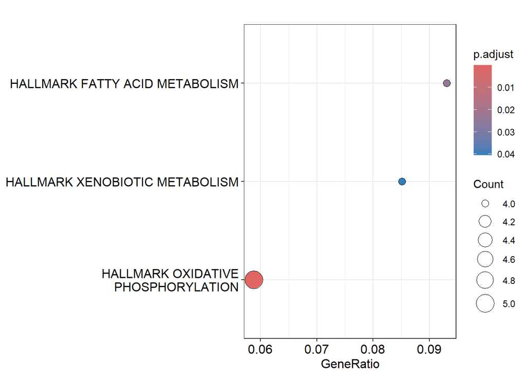

```r
hallmarks <- msigdbr(species = "Homo sapiens", category = "H")
hallmarks <- hallmarks[,c('gs_name', 'gene_symbol')]
dotplot(hm)
```

- Summarize the results based on PCA, clustering, DEG, and GSEA analysis. (up to 250 words)
- Make sure you base your answer on the different steps you made (PCA, clustering, DEG, GSEA)

[output not shown]

Knit your homework as an HTML file and submit it. Eat healthy :)